# Taller evaluado

Un compendio reproducible con datos de la ELSOC

Andrés González-Santa Cruz

Reproducibilidad y Comunicación de Resultados · UDP · 2026

# Parte 1 · Qué se pide

En parejas. Seis pasos. La entrega es un ZIP en Canvas.

## Qué va a entregar

Un ZIP con la carpeta de su proyecto, en Canvas. Adentro va un compendio:

- **El informe**: `informe.qmd` y su `informe.html`, con los nombres de la pareja, la fecha, una tabla de 2 × 2, un gráfico, tres textos cortos y la información de la sesión.
- **Los datos**: la base ELSOC que bajó de GitHub.
- **El entorno**: el guion que armó el compendio, `renv.lock`, `DESCRIPTION` y `README.md`.

Recibe un kit con el proyecto y la plantilla del informe. El guion lo copia de estas láminas y lo completa.

**Lo que se evalúa:** que sepa armar un compendio, completar un documento dinámico, renderizarlo y entregarlo de modo que otra persona lo pueda repetir.

**En parejas.** Cada pareja recibe una opción, del 1 al 5. Se entrega hasta el **domingo 29 de noviembre a las 23:59**.

Vale el 40 % de la nota del curso, según el programa.

## Las cinco opciones

Todas hacen la misma pregunta: **¿difieren hombres y mujeres?** Cambian el año y el tema.

| Opción | Ola | Tema | Variable | Categorías que forman el primer grupo |
| --- | --- | --- | --- | --- |
| **1** | 2016 | Confianza en Carabineros | `conf_carb` | `"Bastante"` y `"Mucho"` |
| **2** | 2017 | Confianza en el Presidente o la Presidenta | `conf_presi` | `"Nada"` |
| **3** | 2018 | Confianza en los partidos políticos | `conf_part` | `"Nada"` |
| **4** | 2019 | Cambiar la Constitución | `cambiar_consti` | `"De acuerdo o totalmente de acuerdo"` |
| **5** | 2018 | Identificación con un partido político | `idpart` | `"Ninguno"` |

El segundo grupo es el resto de las respuestas. Los nombres de los dos grupos y el título del gráfico los decide la pareja.

Use solo la opción que le asignaron. Estos datos se escriben en el código de `informe.qmd`, en el paso 5.

## Ruta: seis pasos

**Armar el compendio**

1. Baje el kit y abra el proyecto.
2. Copie el guion, complételo y ejecútelo.
3. Baje la base desde GitHub.

**El informe y la entrega**

4. Identifique el informe: opción y nombres.
5. Complete el código y renderice.
6. Escriba los textos, comprima y entregue.

Necesita R, RStudio e internet. Tiempo estimado: entre una hora y una hora y media.

Un doble clic amplía cualquier parte de la lámina. Otro doble clic la devuelve.

# Parte 2 · Armar el compendio

Pasos 1 a 3. Al final tendrá las carpetas, los paquetes y los datos.

## Paso 1 · Baje el kit y abra el proyecto

El kit trae dos archivos: el proyecto y la plantilla del informe.

1. Baje kit-taller.zip.
2. En la carpeta de descargas: clic derecho sobre el ZIP y **Extraer todo…** Elija una carpeta corta, por ejemplo `C:\taller`.
3. Entre a esa carpeta y haga doble clic en `TallerELSOC.Rproj`.

**¿Cómo sé que funcionó?** RStudio muestra `TallerELSOC` arriba a la derecha. La pestaña **Files** lista `informe.qmd` y `TallerELSOC.Rproj`.

**Ojo.** Un doble clic sobre el ZIP solo lo muestra por dentro: hay que extraerlo. Si trabaja dentro del ZIP, nada se guarda.

Sin tildes, ñ ni espacios en la ruta. Evite las carpetas de OneDrive y Google Drive.

## Paso 2 · Prepare el compendio

1. En RStudio: **File → New File → R Script**.
2. Copie el guion con el botón de su esquina superior derecha y péguelo.
3. Complete las dos líneas que siguen a cada `INSTRUCCION`.
4. Guárdelo como `00estructura_taller.R`, junto a `TallerELSOC.Rproj`.
5. Presione **Source**. Necesita internet y tarda unos minutos.

```r
# 00estructura_taller.R: prepara el compendio del taller (paso 2). Complete las dos INSTRUCCIONES.
# 1. PAQUETES, fecha que fija sus versiones y CARPETAS
# INSTRUCCION 1 = El informe usa dplyr y ggplot2. Complete el vector con esos dos paquetes.
paquetes <- c("renv", "______", "______", "knitr", "rmarkdown")
fecha    <- "2026-10-03"                       # la misma fecha de la clase 1
# INSTRUCCION 2 = Lea el README de la seccion 7. Que cuatro carpetas debe crear?
carpetas <- c("______", "______", "______", "______")
# 2. COMPROBAR antes de escribir archivos o instalar paquetes
if (!file.exists("TallerELSOC.Rproj")) stop("Abra el proyecto con doble clic en TallerELSOC.Rproj y ejecute de nuevo.")
if (any(grepl("___", c(paquetes, carpetas)))) stop("Complete las dos INSTRUCCIONES de la seccion 1.")
# 3. CARPETAS del compendio
for (carpeta in carpetas) dir.create(carpeta, showWarnings = FALSE)
# 4. DESCRIPTION: que es el proyecto y que paquetes usa (sin datos personales)
writeLines(c("Package: TallerELSOC", "Type: Project", "Version: 0.1.0", "Encoding: UTF-8",
             "Title: Taller evaluado ELSOC, curso Reproducibilidad (UDP 2026)",
             paste("Imports:", paste(paquetes, collapse = ", "))), "DESCRIPTION")
# 5. RENV: biblioteca propia del proyecto, con los paquetes de la fecha fijada (como en la clase 1)
repos <- c(CRAN = paste0("https://packagemanager.posit.co/cran/", fecha))
options(repos = repos, renv.consent = TRUE)    # renv no pregunta la primera vez
if (!file.exists("renv/activate.R")) {         # primera vez: instala renv y crea la biblioteca
  biblioteca <- tempfile("renv-")
  dir.create(biblioteca)
  utils::install.packages("renv", lib = biblioteca, repos = repos)
  .libPaths(c(biblioteca, .libPaths()))
  renv::init(bare = TRUE, restart = FALSE, repos = repos, settings = list(snapshot.type = "explicit", use.cache = FALSE))
} else source("renv/activate.R")               # ya existia: solo la activa
options(repos = repos)
lock <- if (file.exists("renv.lock")) renv::lockfile_read("renv.lock")
if (!is.null(lock) && all(paquetes %in% names(lock$Packages))) {
  renv::restore(prompt = FALSE)                # con renv.lock: instala exactamente lo registrado
} else renv::install(packages = paquetes, repos = repos, prompt = FALSE)   # sin renv.lock: los de la fecha
lock <- renv::snapshot(type = "explicit", repos = repos, lockfile = NULL, prompt = FALSE)
for (p in names(lock$Packages)) {              # algunos binarios de Posit declaran "latest"
  if (identical(lock$Packages[[p]]$Source, "Repository")) lock$Packages[[p]]$Repository <- "CRAN"
}
renv::lockfile_write(lock, file = "renv.lock") # versiones de R y de cada paquete
# 6. ENTORNO: sistema operativo, version de R e idioma del computador
writeLines(capture.output(sessionInfo()), "_doc/entorno.txt")
# 7. README: como instalar las dependencias y ejecutar el proyecto
writeLines(c("# Taller evaluado ELSOC", "",
  "Compendio reproducible del curso Reproducibilidad y Comunicacion de Resultados (UDP 2026).", "",
  "## Como reproducir este informe", "",
  paste0("1. Instale R (este proyecto se hizo con R ", lock$R$Version, ") y RStudio."),
  "2. Descomprima el ZIP y abra `TallerELSOC.Rproj`.",
  "3. En la consola, ejecute `renv::restore()`: instala los paquetes con las versiones de `renv.lock`.",
  "4. Abra `informe.qmd` y presione **Render**.", "",
  "## Datos", "",
  "`_data/elsoc_long.RData`: ELSOC (COES), olas 2016 a 2019, formato largo.",
  "Se bajo de <https://github.com/elsoc-coes/elsoc_ggplot/tree/master/1_input/data>.", "",
  "## Estructura", "",
  "- `informe.qmd` e `informe.html`: el informe y su version renderizada.",
  "- `_data/`: la base de datos, tal como se bajo.",
  "- `_outputs/`: la tabla del informe, `tabla.csv`.",
  "- `_figures/`: el grafico del informe, `grafico.png`.",
  "- `_doc/`: `entorno.txt`, con el sistema operativo, la version de R y el idioma.",
  "- `DESCRIPTION`, `renv.lock`, `renv/` y `.Rprofile`: paquetes, versiones y su activacion."), "README.md")
# 8. COMPROBAR que todo quedo
stopifnot(file.exists("DESCRIPTION", "renv.lock", "README.md", "_doc/entorno.txt"), paquetes %in% rownames(installed.packages()))
message("Listo. Siga con el paso 3: baje la base y guardela en la carpeta de datos.")
```

## Paso 3 · Baje la base desde GitHub

La base está en un repositorio público del COES. Hay que traerla a la carpeta de datos de su proyecto.

1. Abra github.com/elsoc-coes/elsoc_ggplot y entre a `1_input`, después a `data` y después a `elsoc_long.RData`.

[figure not shown]

2. Presione la flecha hacia abajo, **Download raw file**, arriba a la derecha.

[figure not shown]

3. Mueva el archivo desde la carpeta de descargas a la carpeta `_data` del proyecto.

**O con una línea**, en la consola de RStudio:

```r
download.file("https://raw.githubusercontent.com/elsoc-coes/elsoc_ggplot/master/1_input/data/elsoc_long.RData", "_data/elsoc_long.RData", mode = "wb")
```

**¿Cómo sé que funcionó?** En **Files**, dentro de `_data`, está `elsoc_long.RData` y pesa 155,8 KB.

**Ojo con el nombre.** Debe ser exactamente `elsoc_long.RData`. No sirve `elsoc_long (1).RData`. No lo abra con doble clic.

**Si la red bloquea la descarga:** en la página del repositorio, **Code → Download ZIP**. Extraiga y copie `1_input/data/elsoc_long.RData` a `_data`. O use otra red.

# Parte 3 · El informe y la entrega

Pasos 4 a 6. Casi todo ocurre en `informe.qmd`.

## Paso 4 · Identifique el informe

El encabezado dice qué opción es, quién lo hizo y cuándo.

1. En **Files**, abra `informe.qmd`.
2. En la línea 3, cambie `______` por el número de su opción.
3. En la línea 4, cambie `Nombre Apellido y Nombre Apellido` por los dos nombres. Deje las comillas.
4. Guarde con Ctrl + S.

```yaml
subtitle: "Opción 3 · Reproducibilidad y Comunicación de Resultados · UDP 2026"
author: "Camila Rojas y Diego Soto"
date: today
```

**La fecha se escribe sola.** `date: today` pone el día en que se renderiza. Así el informe dice cuándo se produjo de verdad.

**Ojo.** No borre los tres guiones `---` que abren y cierran el encabezado.

## Paso 5 · Complete el código y renderice

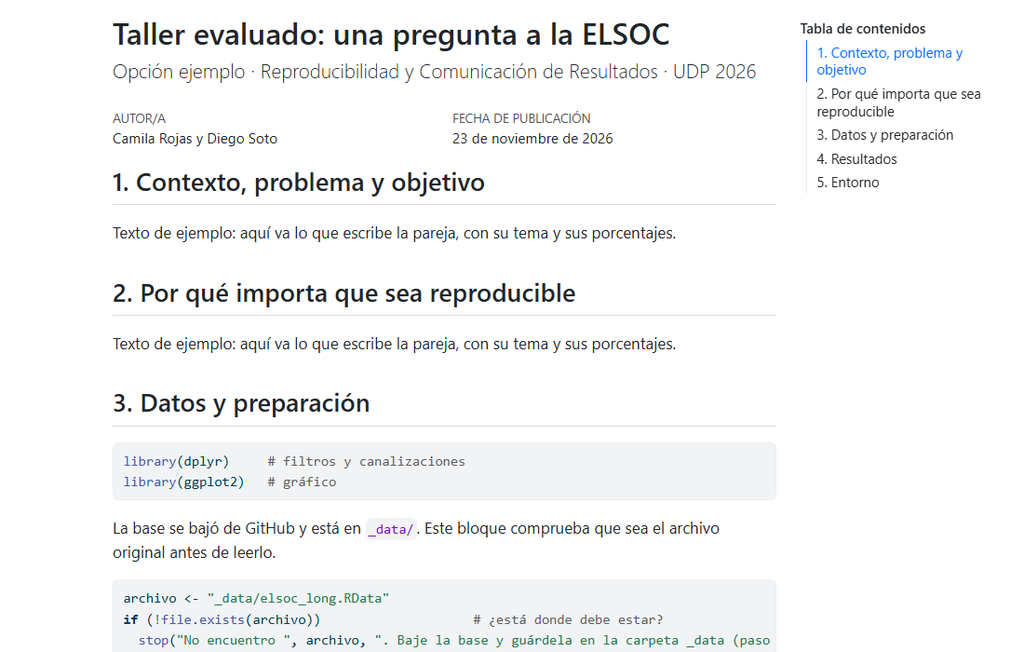

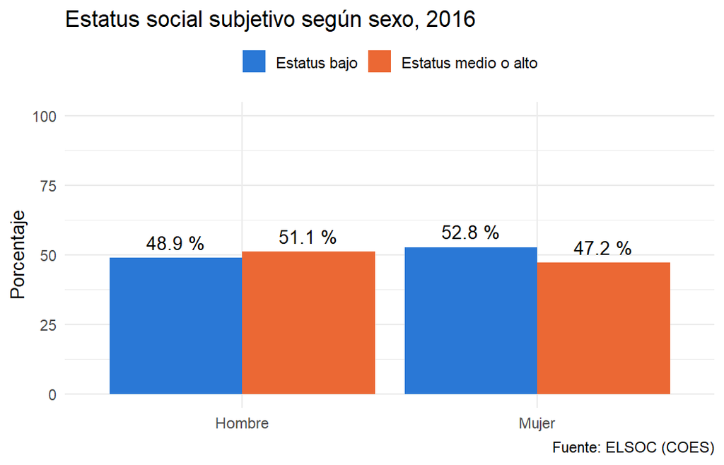

Ejemplo con una variable que no está entre las opciones.

## Paso 6 · Escriba, comprima y entregue

1. Reemplace cada `ESCRIBA AQUÍ` por un texto suyo de tres a cinco líneas y presione **Render**.
2. Cierre RStudio.
3. En la carpeta del proyecto, entre a `renv` y elimine la carpeta `library`. Solo esa.

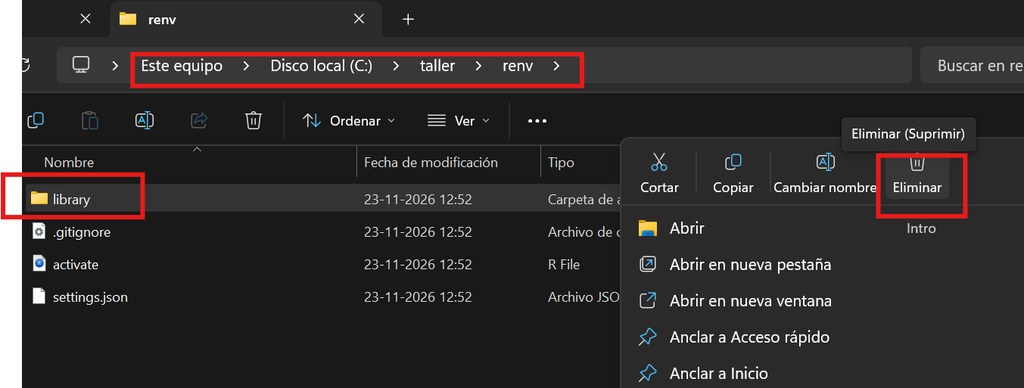

4. Vuelva atrás. Clic derecho sobre la carpeta del proyecto y **Comprimir a… → Archivo ZIP**. En Windows 10: **Enviar a → Carpeta comprimida**.

[figure not shown]

5. Suba el ZIP a la tarea de Canvas, hasta el domingo 29 de noviembre a las 23:59. Una entrega por pareja.

**La entrega está completa si**

- los tres textos nombran su tema y sus porcentajes;
- el ZIP pesa menos de 2 MB;
- trae el informe en `.qmd` y en `.html`, la base, la tabla, el gráfico, el guion y los archivos del entorno;
- otra persona lo repite con `renv::restore()` y **Render**.

`library` guarda los paquetes instalados: 78 MB que se reinstalan con `renv::restore()`. Lo que los describe es `renv.lock`, y ese sí se entrega.

## Criterios de evaluación: 20 puntos

| Criterio | Puntos | Completo | A medias: la mitad de los puntos |
| --- | --- | --- | --- |
| **1. Entrega y compendio** | 2 | El ZIP está en Canvas, sin la carpeta `library`, y trae la base, la tabla, el gráfico, `informe.qmd` e `informe.html`, cada uno en su lugar | Falta una pieza, viene `library` o los archivos llegaron sueltos |
| **2. Entorno y dependencias** | 4 | El guion tiene sus dos instrucciones completas; están `renv.lock`, `DESCRIPTION`, `README.md` y `_doc/entorno.txt`, y el informe termina con la información de la sesión | Falta uno, o una instrucción quedó mal |
| **3. Se repite en otro equipo** | 3 | Con `renv::restore()` y **Render**, el profesor obtiene los mismos números | Corre solo después de corregir una línea |
| **4. Datos de su opción** | 3 | La ola, la variable y las categorías son las de la opción asignada y la tabla de 2 × 2 coincide con la pauta | Un dato no corresponde, o es otra opción |
| **5. Gráfico** | 2 | Título y nombres de grupo propios, que dicen de qué trata | El título o los grupos no dicen de qué trata |
| **6. Documento dinámico** | 2 | Número de opción, nombres de la pareja y fecha; el HTML sale del `.qmd` sin retoques a mano | Falta un dato, o el HTML no coincide con el `.qmd` |
| **7. Tres textos** | 4 | Los tres nombran su tema y sus porcentajes: objetivo, reproducibilidad e interpretación con una limitación | Falta uno, o son genéricos |

Sin evidencia de un criterio, 0 puntos en ese criterio. **Nota 4,0 con 12 puntos; nota 7,0 con 20.**